# M3T2 - Visualize and Analyze Energy Data

# 1 Task Description

Hi,

I have exciting news. We’re about to close a deal with a regional home developer to develop analytics for a new set of electrical sub-metering devices used for power management in Smart Homes. Installing these sub-meters could be a big step towards the developer’s goal of offering highly efficient Smart Homes that providing owners with power usage analytics.

As a starting point, they have provided us with a very large data set that contains 47 months of energy usage data from these devices. Our job over the next few weeks will be to analyze this data to determine what kind of analytics and visualizations can be created that would empower Smart Home owners with greater understanding and control of their power usage.

Since you are new at IOT Analytics, I’ll explain our onboarding process for new clients.

Conduct research to become informed on the client’s business. In this case, you will need to get up to speed on the domains of Smart Homes, sub-meters and household power consumption. Identify any analytic skill/knowledge gaps foreseen for the project and plug those gaps with self-learning. With a data set this big, data munging and sub-setting will be essential to the analytic process. Working with DateTime and Time Series also needs to be mastered. Perform an initial exploration of the data. This exploration should be used to understand any potential issues, conduct early preprocessing, note summary statistics and identify any early recommendations about improvements to future data collection. Hold a project kick-off meeting with the client to close the deal. This meeting will center around a presentation that contains all of the project details and our initial exploration of the data. Your initial task is to work through the onboarding process and produce a PowerPoint presentation that will be delivered to the home developer’s management team during the kick off meeting. This report will give them confidence in our process and convince them that this project is relevant to their business needs.

It is important to remember that we do not know what the data will show, and neither does the home builder; it is your job to tell them how we will conduct the analysis and what they are likely to gain, so be precise and accurate with your findings and any initial recommendations. However, keep in mind that you will be presenting your report to business rather than technical people.

Well, the future of this project is in your capable hands! Gather the required resources and prove that the sub-metering devices will deliver the value the developer seeks through data analytics.

Good luck,

Kathy

VP, IOT Analytics

```r
# Load Libraries
library(caret)
library(tidyverse)
library(readr)
library(RMySQL)
library(lubridate)
library(plyr)
library(dplyr)
library(knitr)
library(skimr)
library(ggplot2)
library(plotly)
library(tidyr)
library(Hmisc)
library(forecast)
library(plotrix)
library(kableExtra)
library(broom)
library(knitr)
library(VIM)
```

# 2 Data Set Feature Definitions

```r
# Create Definitions Table
Energy_submeter_defs <- read.csv("~/XTOL Big Data/Module 3/Task 2 - Visualize and Analyze Energy Data/Energy_submeter_defs.csv")

kable(Energy_submeter_defs, align = 'l', col.names=c('Feature', 'Definition', 'Sub-Meter-Coverage'), caption='Data Set Feature Definitions') %>% kable_styling('striped')
```

Data Set Feature Definitions

| Feature | Definition | Sub-Meter-Coverage |
| --- | --- | --- |
| date: | Date in format dd/mm/yyyy |  |
| time: | Time in format hh:mm:ss |  |
| global_active_power: | household global minute-averaged active power (in kilowatt) |  |
| global_reactive_power: | household global minute-averaged reactive power (in kilowatt) |  |
| voltage: | minute-averaged voltage (in volt) |  |
| global_intensity: | household global minute-averaged current intensity (in ampere) |  |
| sub_metering_1: | energy sub-metering No. 1 (in watt-hour of active energy). | It corresponds to the kitchen, containing mainly a dishwasher, an oven and a microwave (hot plates are not electric but gas powered). |
| sub_metering_2: | energy sub-metering No. 2 (in watt-hour of active energy). | It corresponds to the laundry room, containing a washing-machine, a tumble-drier, a refrigerator and a light. |
| sub_metering_3: | energy sub-metering No. 3 (in watt-hour of active energy). | It corresponds to an electric water-heater and an air-conditioner. |

# 3 Connect to Database

```r
# DB Connection
con = dbConnect(MySQL(), user='deepAnalytics', password='Sqltask1234!', dbname='dataanalytics2018', host='data-analytics-2018.cbrosir2cswx.us-east-1.rds.amazonaws.com')

# Explore the DB
dbListTables(con)
```

# 4 Load Tables

```r
# Load Tables
year_2006 <- dbGetQuery(con, "SELECT * FROM yr_2006")
year_2007 <- dbGetQuery(con, "SELECT * FROM yr_2007")
year_2008 <- dbGetQuery(con, "SELECT * FROM yr_2008")
year_2009 <- dbGetQuery(con, "SELECT * FROM yr_2009")
year_2010 <- dbGetQuery(con, "SELECT * FROM yr_2010")
```

# 5 Investigate Data Types

```r
str(year_2006)
str(year_2007)
str(year_2008)
str(year_2009)
str(year_2010)
```

## 5.1 Comments

2006 contains only 1 month (December) 2007, 2008 and 2009 contains 12 months each 2010 contains 11 months (december is missing)

```r
# Combine Tables
multi_year <- bind_rows(year_2007, year_2008, year_2009)

# Change Feature Names
house_pwr <- multi_year
```

# 6 Data Processing

```r
#-change feature names
colnames(house_pwr)[4] <- 'Glbl_actvPwr'
colnames(house_pwr)[5] <- 'Glbl_ractvPwr'
colnames(house_pwr)[8] <- 'Sub-Meter-1'
colnames(house_pwr)[9] <- 'Sub-Meter-2'
colnames(house_pwr)[10] <- 'Sub-Meter-3'

# Create a column named DateTime
house_pwr$DateTime <- paste(house_pwr$Date, house_pwr$Time)
house_pwr$DateTime <- ymd_hms(house_pwr$DateTime)

# Add Europe/Paris Time Zone
attr(house_pwr$DateTime, "tzone") <- "Europe/Paris"

# Check Range
range(house_pwr$DateTime)
```

```
[1] "2007-01-01 01:00:00 CET" "2010-01-01 00:59:00 CET"
```

```r
# remove data from year 2010
house_pwr <- filter(house_pwr, year(DateTime) != 2010)

# Check NAs
sum(is.na(house_pwr))
```

```
[1] 0
```

```r
# Create Long Form of Data Set
house_pwr_tidy <- house_pwr %>% gather(Meter, Watt_hr, `Sub-Meter-1`, `Sub-Meter-2`, `Sub-Meter-3`)

#-Convert meter feature to categorical
house_pwr_tidy$Meter <- factor(house_pwr_tidy$Meter)

#-peak at data
glimpse(house_pwr_tidy)
```

```
Observations: 4,709,502
Variables: 10
$ id               <dbl> 1, 2, 3, 4, 5, 6, 7, 8, 9, 10, 11, 12, 13, 14, 15, 16, 17, 18, 19, 20, 21, 22, 23, 24, 25, 26, 27, 28,...
$ Date             <chr> "2007-01-01", "2007-01-01", "2007-01-01", "2007-01-01", "2007-01-01", "2007-01-01", "2007-01-01", "200...
$ Time             <chr> "00:00:00", "00:01:00", "00:02:00", "00:03:00", "00:04:00", "00:05:00", "00:06:00", "00:07:00", "00:08...
$ Glbl_actvPwr     <dbl> 2.580, 2.552, 2.550, 2.550, 2.554, 2.550, 2.534, 2.484, 2.468, 2.486, 2.492, 2.500, 2.494, 2.492, 2.48...
$ Glbl_ractvPwr    <dbl> 0.136, 0.100, 0.100, 0.100, 0.100, 0.100, 0.096, 0.000, 0.000, 0.000, 0.000, 0.000, 0.000, 0.000, 0.00...
$ Global_intensity <dbl> 10.6, 10.4, 10.4, 10.4, 10.4, 10.4, 10.4, 10.2, 10.2, 10.2, 10.2, 10.2, 10.2, 10.2, 10.2, 10.2, 10.2, ...
$ Voltage          <dbl> 241.97, 241.75, 241.64, 241.71, 241.98, 241.83, 241.07, 241.29, 241.23, 242.18, 242.46, 242.88, 242.57...
$ DateTime         <dttm> 2007-01-01 01:00:00, 2007-01-01 01:01:00, 2007-01-01 01:02:00, 2007-01-01 01:03:00, 2007-01-01 01:04:...
$ Meter            <fct> Sub-Meter-1, Sub-Meter-1, Sub-Meter-1, Sub-Meter-1, Sub-Meter-1, Sub-Meter-1, Sub-Meter-1, Sub-Meter-1...
$ Watt_hr          <dbl> 0, 0, 0, 0, 0, 0, 0, 0, 0, 0, 0, 0, 0, 0, 0, 0, 0, 0, 0, 0, 0, 0, 0, 0, 0, 0, 0, 0, 0, 0, 0, 0, 0, 0, ...
```

# 7 Visualizations of Energy Usage Across Sub-Meters and Time Periods

## 7.1 Yearly Time Period

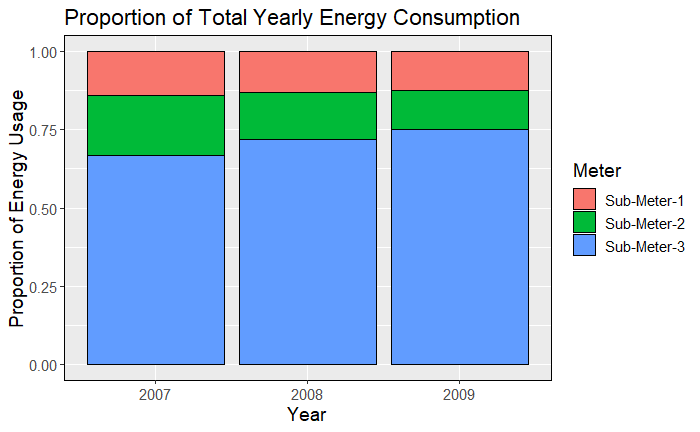

```r
#-Year_Proportional Plot
house_pwr_tidy %>%
  group_by(year(DateTime), Meter) %>%
  summarise(sum=sum(Watt_hr)) %>%
  ggplot(aes(x=factor(`year(DateTime)`), sum, group=Meter,fill=Meter)) +
  labs(x='Year', y='Proportion of Energy Usage') +
  ggtitle('Proportion of Total Yearly Energy Consumption') +
  geom_bar(stat='identity', position='fill', color='black') +
  theme(panel.border=element_rect(colour='black', fill=NA)) +
  theme(text = element_text(size = 14))
```

## 7.2 Quaterly Time Period

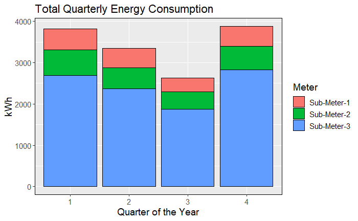

```r
#-Quarterly bar plot
house_pwr_tidy %>%
  filter(year(DateTime)<2010) %>%
  group_by(quarter(DateTime), Meter) %>%
  summarise(sum=round(sum(Watt_hr/1000),3)) %>%
  ggplot(aes(x=factor(`quarter(DateTime)`), y=sum)) +
  labs(x='Quarter of the Year', y='kWh') +
  ggtitle('Total Quarterly Energy Consumption') +
  geom_bar(stat='identity', aes(fill = Meter), color='black') +
  theme(panel.border=element_rect(colour='black', fill=NA)) +
  theme(text = element_text(size = 14))
```

## 7.3 Monthly Time Period

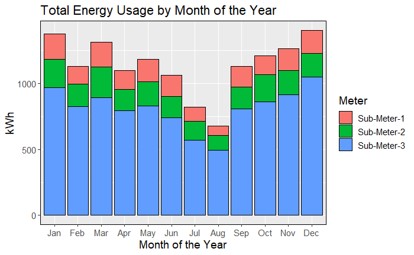

```r
#-Monthly bar chart
house_pwr_tidy %>%
  filter(year(DateTime)<2010) %>%
  mutate(Month=lubridate::month(DateTime, label=TRUE, abbr=TRUE)) %>%
  group_by(Month, Meter) %>%
  summarise(sum=round(sum(Watt_hr)/1000),3) %>%
  ggplot(aes(x=factor(Month), y=sum)) +
    labs(x='Month of the Year', y='kWh') +
    ggtitle('Total Energy Usage by Month of the Year') +
    geom_bar(stat='identity', aes(fill = Meter), colour='black') +
  theme(panel.border=element_rect(colour='black', fill=NA)) +
  theme(text = element_text(size = 14))
```

## 7.4 Weekly Time Period

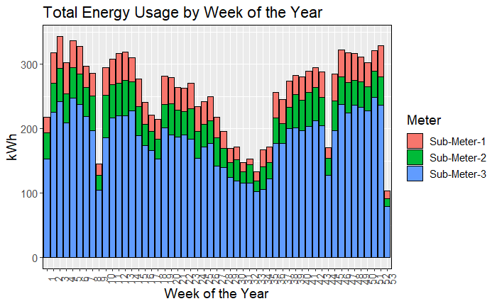

```r
#-Week of the year- bar plot
house_pwr_tidy %>%
  group_by(week(DateTime), Meter) %>%
  summarise(sum=sum(Watt_hr/1000)) %>%
  ggplot(aes(x=factor(`week(DateTime)`), y=sum)) +
    labs(x='Week of the Year', y='kWh') +
    ggtitle('Total Energy Usage by Week of the Year') +
    theme(axis.text.x = element_text(angle=90)) +
    geom_bar(stat='identity', aes(fill=Meter), colour='black') +
  theme(panel.border=element_rect(colour='black', fill=NA)) +
  theme(text = element_text(size = 14))
```

## 7.5 Hourly Time Period

```
longer object length is not a multiple of shorter object length
```

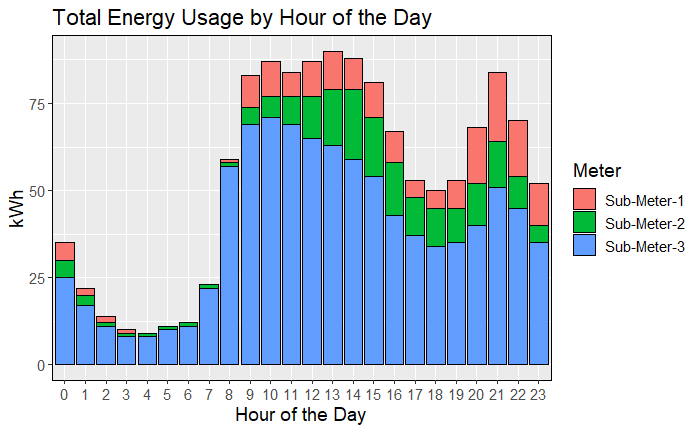

```r
#-Hour of day bar chart
house_pwr_tidy %>%
  filter(month(DateTime) == c(1,2,11,12)) %>%
  group_by(hour(DateTime), Meter) %>%
  summarise(sum=round(sum(Watt_hr)/1000),3) %>%
  ggplot(aes(x=factor(`hour(DateTime)`), y=sum)) +
  labs(x='Hour of the Day', y='kWh') +
  ggtitle('Total Energy Usage by Hour of the Day') +
  geom_bar(stat='identity', aes(fill = Meter), colour='black') +
  theme(panel.border=element_rect(colour='black', fill=NA)) +
  theme(text = element_text(size = 14))
```

# 8 Compare Energy Consumption for Day of Week (Summer & Winter)

## 8.1 Winter

```
longer object length is not a multiple of shorter object length
```

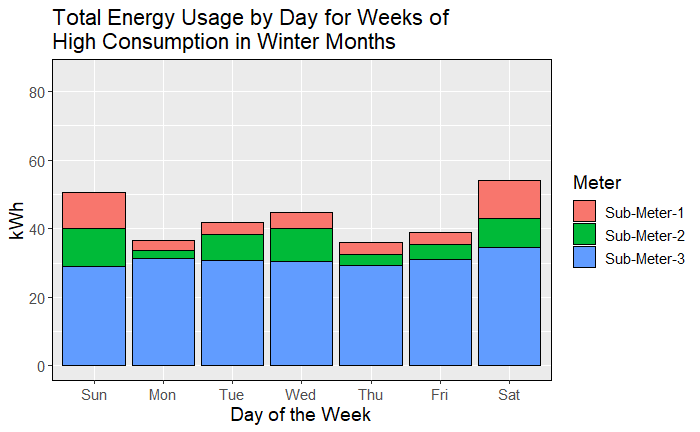

```r
#-Filter and plot data for weeks 1-8
house_pwr_tidy %>%
  filter(week(DateTime) == c(1:8)) %>%
  mutate(Day=lubridate::wday(DateTime, label=TRUE, abbr=TRUE)) %>%
  group_by(Day, Meter) %>%
  summarise(sum=sum(Watt_hr/1000)) %>%
  ggplot(aes(x=factor(Day), y=sum)) +
  labs(x='Day of the Week', y='kWh') +
  ylim(0,85) +
  ggtitle('Total Energy Usage by Day for Weeks of \nHigh Consumption in Winter Months') +
  geom_bar(stat='identity', aes(fill = Meter), colour='black') +
  theme(panel.border=element_rect(colour='black', fill=NA)) +
  theme(text = element_text(size = 14))
```

## 8.2 Summer

```
longer object length is not a multiple of shorter object length
```

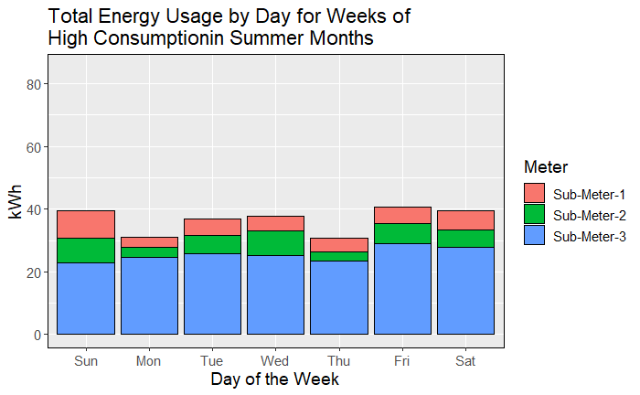

```r
#-Filter and plot data for weeks 18-25
house_pwr_tidy %>%
  filter(week(DateTime) == c(18:25)) %>%
  mutate(Day=lubridate::wday(DateTime, label=TRUE, abbr=TRUE)) %>%
  group_by(Day, Meter) %>%
  summarise(sum=sum(Watt_hr/1000)) %>%
  ggplot(aes(x=factor(Day), y=sum)) +
  labs(x='Day of the Week', y='kWh') +
  ylim(0,85) +
  ggtitle('Total Energy Usage by Day for Weeks of \nHigh Consumptionin Summer Months') +
  geom_bar(stat='identity', aes(fill = Meter), colour='black') +
  theme(panel.border=element_rect(colour='black', fill=NA)) +
  theme(text = element_text(size = 14))
```

## 8.3 Summary Plot

```r
#-Subset data for weeks 1-8 and assign to variable w
w <- house_pwr_tidy %>%
  filter(week(DateTime) == c(1:8)) %>%
  filter(Meter == 'Sub-Meter-3') %>%
  mutate(Day=lubridate::wday(DateTime, label=TRUE, abbr=TRUE)) %>%
  group_by(Day, Meter) %>%
  summarise(sum=sum(Watt_hr/1000))
```

```
longer object length is not a multiple of shorter object length
```

```r
#-Subset data for weeks 18-25 and assign to variable ww
ww <- house_pwr_tidy %>%
  filter(week(DateTime) == c(18:25)) %>%
  filter(Meter == 'Sub-Meter-3') %>%
  mutate(Day=lubridate::wday(DateTime, label=TRUE, abbr=TRUE)) %>%
  group_by(Day, Meter) %>%
  summarise(sum=sum(Watt_hr/1000))
```

```
longer object length is not a multiple of shorter object length
```

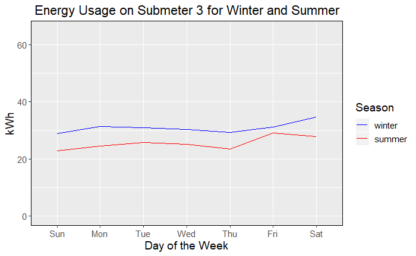

```r
#-Overlay line plots of the two 8-week time periods
ggplot(w) +
  labs(x='Day of the Week', y='kWh') +
  ylim(0,65) +
  ggtitle(' Energy Usage on Submeter 3 for Winter and Summer') +
  geom_line(aes(x=Day, y=sum, group=1,colour='winter')) +
  geom_line(data = ww, aes(x=Day, y=sum, group=1, color='summer')) +
  scale_colour_manual(values=c('winter'='blue', 'summer'='red')) +
  labs(colour='Season') +
  guides(colour=guide_legend(reverse=TRUE)) +
  theme(panel.border=element_rect(colour='black', fill=NA))+
  theme(text = element_text(size = 14))
```

# 9 Subset Data Set by Time Periods of Year, Quarters and Months

```r
#-Subset data by year and summarise total usage across the 3 submeters
housePWR_year <- house_pwr %>%
  group_by(year(DateTime)) %>%
  summarise(Sub_Meter_1=round(sum(`Sub-Meter-1`/1000), 3),
            Sub_Meter_2=round(sum(`Sub-Meter-2`/1000), 3),
            Sub_Meter_3=round(sum(`Sub-Meter-3`/1000), 3))

#-Look at top several rows of new yearly data set
head(housePWR_year)
```

| year(DateTime) | Sub_Meter_1 | Sub_Meter_2 | Sub_Meter_3 |
| --- | --- | --- | --- |
| 2007 | 642.548 | 854.356 | 3021.773 |
| 2008 | 584.784 | 661.877 | 3180.254 |
| 2009 | 592.657 | 592.177 | 3555.717 |

```r
#-Subset data by quarter and summarise total usage across the 3 submeters
housePWR_qtr <- house_pwr %>%
  group_by(year(DateTime), quarter(DateTime)) %>%
  summarise(Sub_Meter_1=round(sum(`Sub-Meter-1`/1000), 3),
            Sub_Meter_2=round(sum(`Sub-Meter-2`/1000), 3),
            Sub_Meter_3=round(sum(`Sub-Meter-3`/1000), 3))

#-Look at top several rows of new quarterly data set
head(housePWR_qtr)
```

| year(DateTime) | quarter(DateTime) | Sub_Meter_1 | Sub_Meter_2 | Sub_Meter_3 |
| --- | --- | --- | --- | --- |
| 2007 | 1 | 164.775 | 248.549 | 888.087 |
| 2007 | 2 | 177.498 | 180.578 | 609.770 |
| 2007 | 3 | 132.144 | 180.649 | 604.685 |
| 2007 | 4 | 168.131 | 244.580 | 919.231 |
| 2008 | 1 | 164.521 | 198.780 | 846.697 |
| 2008 | 2 | 169.434 | 193.245 | 877.596 |

```r
#-Subset data by month and summarise total energy usage across submeters
housePWR_mnth <- house_pwr %>%
  group_by(year(DateTime), month(DateTime)) %>%
  summarise(Sub_Meter_1=round(sum(`Sub-Meter-1`/1000), 3),
            Sub_Meter_2=round(sum(`Sub-Meter-2`/1000), 3),
            Sub_Meter_3=round(sum(`Sub-Meter-3`/1000), 3))

#-Look at top several rows of new monthly data set
head(housePWR_mnth)
```

| year(DateTime) | month(DateTime) | Sub_Meter_1 | Sub_Meter_2 | Sub_Meter_3 |
| --- | --- | --- | --- | --- |
| 2007 | 1 | 56.433 | 79.251 | 329.578 |
| 2007 | 2 | 47.584 | 64.623 | 270.274 |
| 2007 | 3 | 60.758 | 104.675 | 288.235 |
| 2007 | 4 | 41.591 | 38.446 | 191.629 |
| 2007 | 5 | 76.235 | 72.151 | 228.526 |
| 2007 | 6 | 59.672 | 69.981 | 189.615 |

```r
NA
```

# 10 Convert to Time Series and Plot

## 10.1 Monthly Time Series

```r
#-Create monthly time series
housePWR_mnthTS <- ts(housePWR_mnth[,3:5],
                      frequency = 12,
                      start=c(2007,1),
                      end=c(2009,12))

#-Plot monthly time series
plot(housePWR_mnthTS,
     plot.type='s',
     xlim=c(2007, 2010),
     col=c('red', 'green', 'blue'),
     main='Total Monthly kWh Consumption',
     xlab='Year/Month', ylab = 'kWh')
minor.tick(nx=12)
```

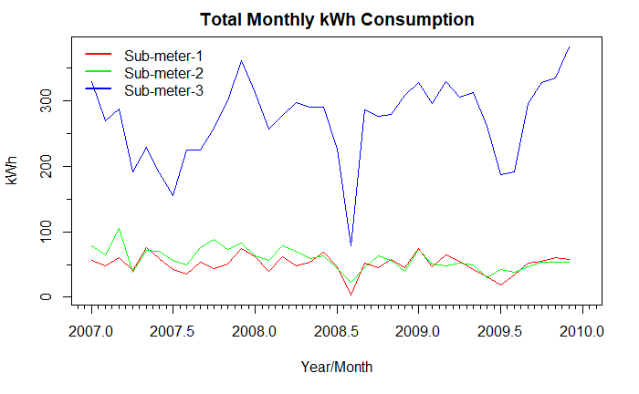

```r
#-Create legend
b <- c('Sub-meter-1', 'Sub-meter-2', 'Sub-meter-3')
legend('topleft', b, col=c('red', 'green', 'blue'), lwd=2, bty='n')
```

## 10.2 Fit Linear Regression Model to Monthly Time Series for Sub Meters 1, 2 and 3

```r
# Sub Meter 1
#-Fit linear model to montly time series for submeter 1
fitmonth1 <- tslm(housePWR_mnthTS[,1] ~ trend + season)

#-One-row statistical summary of monthly linear model
glance(fitmonth1)
```

| r.squared | adj.r.squared | sigma | statistic | p.value | df | logLik | AIC | BIC | deviance | df.residual |
| --- | --- | --- | --- | --- | --- | --- | --- | --- | --- | --- |
| 0.5795754 | 0.3602235 | 11.79856 | 2.642217 | 0.02185954 | 13 | -131.8645 | 291.729 | 313.8983 | 3201.736 | 23 |

```
    Breusch-Godfrey test for serial correlation of order up to 16

data:  Residuals from Linear regression model
LM test = 24.348, df = 16, p-value = 0.08217
```

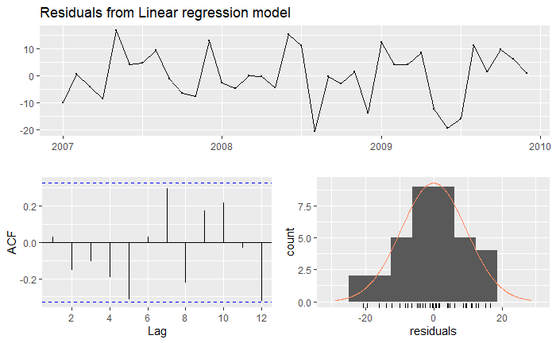

```r
# Summary analysis of residuals
checkresiduals(fitmonth1)
```

```r
# Sub Meter 2
#-Fit linear model to montly time series for submeter 2
fitmonth2 <- tslm(housePWR_mnthTS[,2] ~ trend + season)

#-One-row statistical summary of monthly linear model
glance(fitmonth2)
```

| r.squared | adj.r.squared | sigma | statistic | p.value | df | logLik | AIC | BIC | deviance | df.residual |
| --- | --- | --- | --- | --- | --- | --- | --- | --- | --- | --- |
| 0.6518247 | 0.470168 | 12.47044 | 3.588223 | 0.004130483 | 13 | -133.8583 | 295.7167 | 317.8859 | 3576.772 | 23 |

```
    Breusch-Godfrey test for serial correlation of order up to 16

data:  Residuals from Linear regression model
LM test = 19.748, df = 16, p-value = 0.2318
```

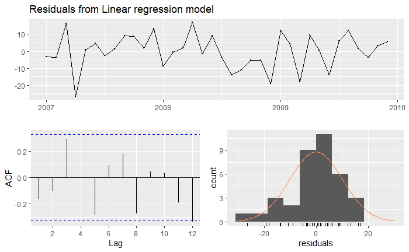

```r
# Summary analysis of residuals
checkresiduals(fitmonth2)
```

```r
# Sub Meter 3
#-Fit linear model to montly time series for submeter 3
fitmonth3 <- tslm(housePWR_mnthTS[,3] ~ trend + season)

#-One-row statistical summary of monthly linear model
glance(fitmonth3)
```

| r.squared | adj.r.squared | sigma | statistic | p.value | df | logLik | AIC | BIC | deviance | df.residual |
| --- | --- | --- | --- | --- | --- | --- | --- | --- | --- | --- |
| 0.756628 | 0.6296512 | 37.58898 | 5.958793 | 0.0001292264 | 13 | -173.5789 | 375.1579 | 397.3271 | 32497.42 | 23 |

```
    Breusch-Godfrey test for serial correlation of order up to 16

data:  Residuals from Linear regression model
LM test = 19.389, df = 16, p-value = 0.249
```

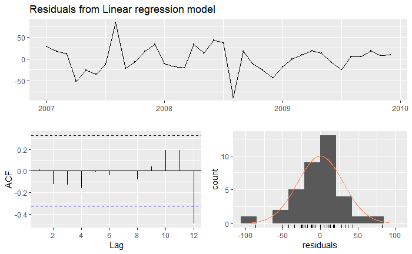

```r
# Summary analysis of residuals
checkresiduals(fitmonth3)
```

# 11 Forecast of Energy Consumption

## 11.1 Monthly Forecast

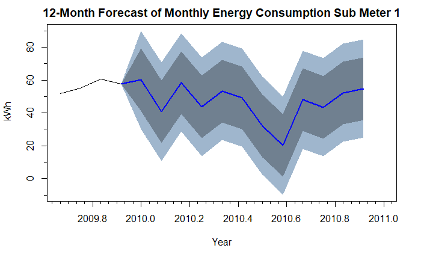

```r
# Sub Meter 1
#-Forecast 12-months of energy usage
y1 <- forecast(fitmonth1,h=12, level=c(80,95))

#-Plot 12-months forecast of energy usage
plot(y1, showgap=FALSE, include=4,
  shadecols=c('slategray3','slategray'),
  xlab ='Year',
  ylab=' kWh',
  main='12-Month Forecast of Monthly Energy Consumption Sub Meter 1')
minor.tick(nx=6)
```

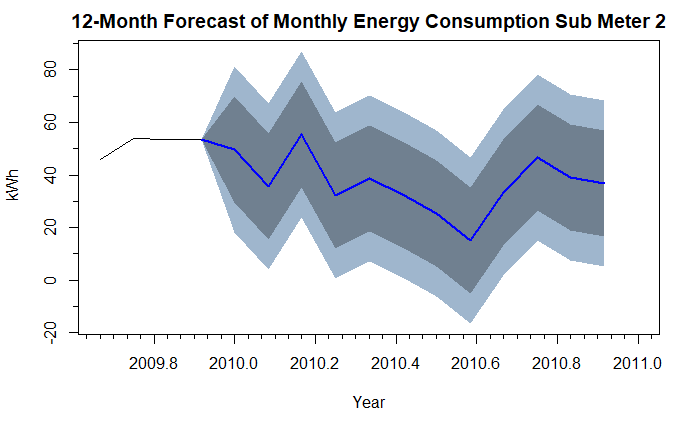

```r
# Sub Meter 2
#-Forecast 12-months of energy usage
y2 <- forecast(fitmonth2,h=12, level=c(80,95))

#-Plot 12-months forecast of energy usage
plot(y2, showgap=FALSE, include=4,
  shadecols=c('slategray3','slategray'),
  xlab ='Year',
  ylab=' kWh',
  main='12-Month Forecast of Monthly Energy Consumption Sub Meter 2')
minor.tick(nx=6)
```

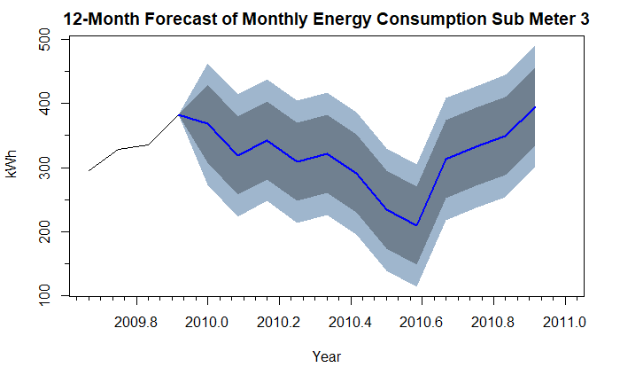

```r
# Sub Meter 3
#-Forecast 12-months of energy usage
y3 <- forecast(fitmonth3,h=12, level=c(80,95))

#-Plot 12-months forecast of energy usage
plot(y3, showgap=FALSE, include=4,
  shadecols=c('slategray3','slategray'),
  xlab ='Year',
  ylab=' kWh',
  main='12-Month Forecast of Monthly Energy Consumption Sub Meter 3')
minor.tick(nx=6)
```

```r
# RMSE and R2 Values
#Sub Meter 1
summary(fitmonth1)
```

```
Call:
tslm(formula = housePWR_mnthTS[, 1] ~ trend + season)

Residuals:
     Min       1Q   Median       3Q      Max
-20.5227  -5.2109   0.2289   6.7287  16.7009

Coefficients:
            Estimate Std. Error t value Pr(>|t|)
(Intercept)  66.5334     7.2945   9.121 4.21e-09 ***
trend        -0.1732     0.2007  -0.863 0.396965
season2     -19.1498     9.6356  -1.987 0.058912 .
season3      -1.2779     9.6418  -0.133 0.895715
season4     -15.8553     9.6523  -1.643 0.114059
season5      -6.1331     9.6669  -0.634 0.532053
season6      -9.9868     9.6856  -1.031 0.313215
season7     -27.0449     9.7085  -2.786 0.010509 *
season8     -38.6730     9.7354  -3.972 0.000602 ***
season9     -10.6398     9.7664  -1.089 0.287246
season10    -15.0386     9.8014  -1.534 0.138589
season11     -6.1040     9.8403  -0.620 0.541155
season12     -3.3764     9.8832  -0.342 0.735728
---
Signif. codes:  0 ‘***’ 0.001 ‘**’ 0.01 ‘*’ 0.05 ‘.’ 0.1 ‘ ’ 1

Residual standard error: 11.8 on 23 degrees of freedom
Multiple R-squared:  0.5796,    Adjusted R-squared:  0.3602
F-statistic: 2.642 on 12 and 23 DF,  p-value: 0.02186
```

```r
#Sub Meter 2
summary(fitmonth2)
```

```
Call:
tslm(formula = housePWR_mnthTS[, 2] ~ trend + season)

Residuals:
    Min      1Q  Median      3Q     Max
-26.462  -4.047   1.225   6.742  16.873

Coefficients:
            Estimate Std. Error t value Pr(>|t|)
(Intercept)  83.5381     7.7099  10.835 1.65e-10 ***
trend        -0.9103     0.2121  -4.292 0.000272 ***
season2     -13.4637    10.1843  -1.322 0.199165
season3       7.5310    10.1909   0.739 0.467386
season4     -14.9883    10.2019  -1.469 0.155335
season5      -7.6846    10.2174  -0.752 0.459611
season6     -12.7286    10.2372  -1.243 0.226256
season7     -19.0066    10.2613  -1.852 0.076867 .
season8     -28.3286    10.2898  -2.753 0.011324 *
season9      -9.1129    10.3225  -0.883 0.386468
season10      4.8841    10.3595   0.471 0.641754
season11     -1.5942    10.4007  -0.153 0.879513
season12     -3.0656    10.4460  -0.293 0.771798
---
Signif. codes:  0 ‘***’ 0.001 ‘**’ 0.01 ‘*’ 0.05 ‘.’ 0.1 ‘ ’ 1

Residual standard error: 12.47 on 23 degrees of freedom
Multiple R-squared:  0.6518,    Adjusted R-squared:  0.4702
F-statistic: 3.588 on 12 and 23 DF,  p-value: 0.00413
```

```r
#Sub Meter 3
summary(fitmonth3)
```

```
Call:
tslm(formula = housePWR_mnthTS[, 3] ~ trend + season)

Residuals:
    Min      1Q  Median      3Q     Max
-86.828 -18.452   4.621  17.636  82.260

Coefficients:
             Estimate Std. Error t value Pr(>|t|)
(Intercept)  299.3194    23.2394  12.880 5.32e-12 ***
trend          1.8540     0.6394   2.900 0.008080 **
season2      -50.6066    30.6979  -1.649 0.112837
season3      -28.8006    30.7179  -0.938 0.358200
season4      -63.9263    30.7512  -2.079 0.048974 *
season5      -53.8902    30.7977  -1.750 0.093482 .
season6      -86.0272    30.8573  -2.788 0.010457 *
season7     -144.5518    30.9301  -4.673 0.000105 ***
season8     -171.1338    31.0159  -5.518 1.30e-05 ***
season9      -69.3318    31.1146  -2.228 0.035925 *
season10     -52.6008    31.2261  -1.685 0.105607
season11     -36.9817    31.3502  -1.180 0.250205
season12       7.0180    31.4869   0.223 0.825592
---
Signif. codes:  0 ‘***’ 0.001 ‘**’ 0.01 ‘*’ 0.05 ‘.’ 0.1 ‘ ’ 1

Residual standard error: 37.59 on 23 degrees of freedom
Multiple R-squared:  0.7566,    Adjusted R-squared:  0.6297
F-statistic: 5.959 on 12 and 23 DF,  p-value: 0.0001292
```

```r
#-Summary of 12-month forecast
summary(y1)
```

```
Forecast method: Linear regression model

Model Information:

Call:
tslm(formula = housePWR_mnthTS[, 1] ~ trend + season)

Coefficients:
(Intercept)        trend      season2      season3      season4      season5      season6      season7      season8      season9
    66.5334      -0.1732     -19.1498      -1.2779     -15.8553      -6.1331      -9.9868     -27.0449     -38.6730     -10.6398
   season10     season11     season12
   -15.0386      -6.1040      -3.3764


Error measures:
             ME     RMSE      MAE       MPE     MAPE      MASE       ACF1
Training set  0 9.430647 7.512428 -16.67715 30.36601 0.6255426 0.03005857

Forecasts:
```

|  | Point Forecast | Lo 80 | Hi 80 | Lo 95 | Hi 95 |
| --- | --- | --- | --- | --- | --- |
| Jan 2010 | 60.12375 | 41.057259 | 79.19024 | 30.231192 | 90.01631 |
| Feb 2010 | 40.80075 | 21.734259 | 59.86724 | 10.908192 | 70.69331 |
| Mar 2010 | 58.49942 | 39.432925 | 77.56591 | 28.606858 | 88.39198 |
| Apr 2010 | 43.74875 | 24.682259 | 62.81524 | 13.856192 | 73.64131 |
| May 2010 | 53.29775 | 34.231259 | 72.36424 | 23.405192 | 83.19031 |
| Jun 2010 | 49.27075 | 30.204259 | 68.33724 | 19.378192 | 79.16331 |
| Jul 2010 | 32.03942 | 12.972925 | 51.10591 | 2.146858 | 61.93198 |
| Aug 2010 | 20.23808 | 1.171592 | 39.30457 | -9.654475 | 50.13064 |
| Sep 2010 | 48.09808 | 29.031592 | 67.16457 | 18.205525 | 77.99064 |
| Oct 2010 | 43.52608 | 24.459592 | 62.59257 | 13.633525 | 73.41864 |

[output cut: 2 more lines]

```r
summary(y2)
```

```
Forecast method: Linear regression model

Model Information:

Call:
tslm(formula = housePWR_mnthTS[, 2] ~ trend + season)

Coefficients:
(Intercept)        trend      season2      season3      season4      season5      season6      season7      season8      season9
    83.5381      -0.9103     -13.4637       7.5310     -14.9883      -7.6846     -12.7286     -19.0066     -28.3286      -9.1129
   season10     season11     season12
     4.8841      -1.5942      -3.0656


Error measures:
                        ME     RMSE     MAE       MPE     MAPE      MASE       ACF1
Training set -9.854193e-17 9.967686 7.77397 -3.617179 15.79527 0.4568635 -0.1621448

Forecasts:
```

|  | Point Forecast | Lo 80 | Hi 80 | Lo 95 | Hi 95 |
| --- | --- | --- | --- | --- | --- |
| Jan 2010 | 49.85542 | 29.703162 | 70.00767 | 18.2605922 | 81.45024 |
| Feb 2010 | 35.48142 | 15.329162 | 55.63367 | 3.8865922 | 67.07624 |
| Mar 2010 | 55.56575 | 35.413495 | 75.71800 | 23.9709255 | 87.16057 |
| Apr 2010 | 32.13608 | 11.983829 | 52.28834 | 0.5412588 | 63.73091 |
| May 2010 | 38.52942 | 18.377162 | 58.68167 | 6.9345922 | 70.12424 |
| Jun 2010 | 32.57508 | 12.422829 | 52.72734 | 0.9802588 | 64.16991 |
| Jul 2010 | 25.38675 | 5.234495 | 45.53900 | -6.2080745 | 56.98157 |
| Aug 2010 | 15.15442 | -4.997838 | 35.30667 | -16.4404078 | 46.74924 |
| Sep 2010 | 33.45975 | 13.307495 | 53.61200 | 1.8649255 | 65.05457 |
| Oct 2010 | 46.54642 | 26.394162 | 66.69867 | 14.9515922 | 78.14124 |

[output cut: 2 more lines]

```r
summary(y3)
```

```
Forecast method: Linear regression model

Model Information:

Call:
tslm(formula = housePWR_mnthTS[, 3] ~ trend + season)

Coefficients:
(Intercept)        trend      season2      season3      season4      season5      season6      season7      season8      season9
    299.319        1.854      -50.607      -28.801      -63.926      -53.890      -86.027     -144.552     -171.134      -69.332
   season10     season11     season12
    -52.601      -36.982        7.018


Error measures:
                        ME     RMSE      MAE       MPE     MAPE      MASE       ACF1
Training set -1.973344e-15 30.04507 23.33889 -2.874058 11.26469 0.4693884 0.01545568

Forecasts:
```

|  | Point Forecast | Lo 80 | Hi 80 | Lo 95 | Hi 95 |
| --- | --- | --- | --- | --- | --- |
| Jan 2010 | 367.9163 | 307.1725 | 428.6602 | 272.6817 | 463.1509 |
| Feb 2010 | 319.1637 | 258.4198 | 379.9075 | 223.9291 | 414.3983 |
| Mar 2010 | 342.8237 | 282.0798 | 403.5675 | 247.5891 | 438.0583 |
| Apr 2010 | 309.5520 | 248.8081 | 370.2959 | 214.3174 | 404.7866 |
| May 2010 | 321.4420 | 260.6981 | 382.1859 | 226.2074 | 416.6766 |
| Jun 2010 | 291.1590 | 230.4151 | 351.9029 | 195.9244 | 386.3936 |
| Jul 2010 | 234.4883 | 173.7445 | 295.2322 | 139.2537 | 329.7229 |
| Aug 2010 | 209.7603 | 149.0165 | 270.5042 | 114.5257 | 304.9949 |
| Sep 2010 | 313.4163 | 252.6725 | 374.1602 | 218.1817 | 408.6509 |
| Oct 2010 | 332.0013 | 271.2575 | 392.7452 | 236.7667 | 427.2359 |

[output cut: 2 more lines]

# 12 Decomposing a Seasonal Time Series

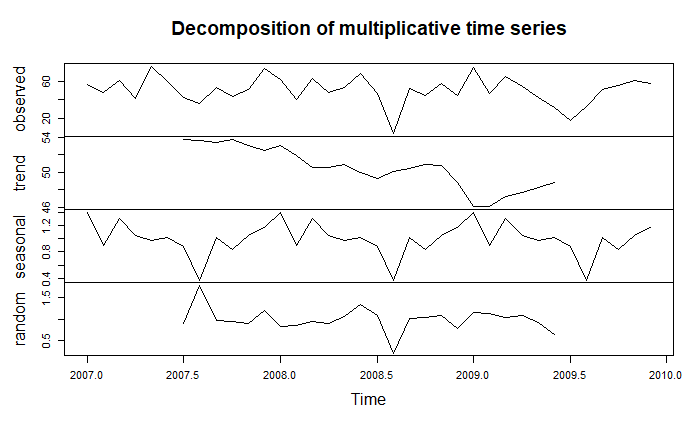

```r
# Decompose Sub Meter 1
#-Create monthly time series for Submeter1
housePWR_mnthTS1 <- ts(housePWR_mnth[,3],
                      frequency = 12,
                      start=c(2007,1),
                      end=c(2009,12))

## Decompose Sub-meter 1 into trend, seasonal and remainder
components_mnthTS1 <- decompose(housePWR_mnthTS1, "multiplicative")

## Plot decomposed all sub-meters
plot(components_mnthTS1)
```

```r
## Check summary statistics for decomposed sub-meter 3
summary(components_mnthTS1)
```

```
         Length Class  Mode
x        36     ts     numeric
seasonal 36     ts     numeric
trend    36     ts     numeric
random   36     ts     numeric
figure   12     -none- numeric
type      1     -none- character
```

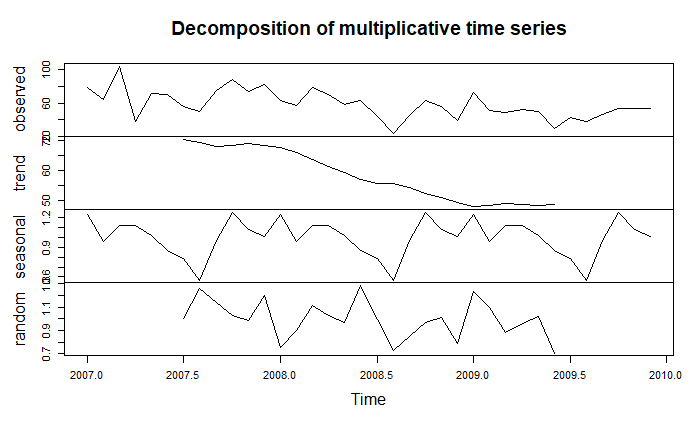

```r
# Decompose Sub Meter 2
#-Create monthly time series for Submeter1
housePWR_mnthTS2 <- ts(housePWR_mnth[,4],
                      frequency = 12,
                      start=c(2007,1),
                      end=c(2009,12))

## Decompose Sub-meter 2 into trend, seasonal and remainder
components_mnthTS2 <- decompose(housePWR_mnthTS2, "multiplicative")

## Plot decomposed all sub-meters
plot(components_mnthTS2)
```

```r
## Check summary statistics for decomposed sub-meter 3
summary(components_mnthTS2)
```

```
         Length Class  Mode
x        36     ts     numeric
seasonal 36     ts     numeric
trend    36     ts     numeric
random   36     ts     numeric
figure   12     -none- numeric
type      1     -none- character
```

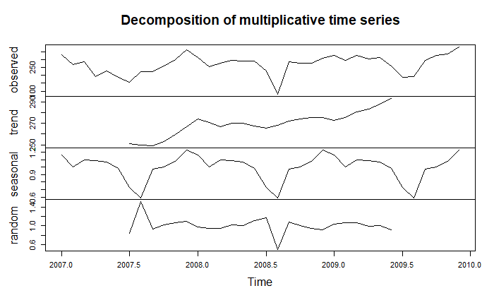

```r
# Decompose Sub Meter 3
#-Create monthly time series for Submeter1
housePWR_mnthTS3 <- ts(housePWR_mnth[,5],
                      frequency = 12,
                      start=c(2007,1),
                      end=c(2009,12))

## Decompose Sub-meter 3 into trend, seasonal and remainder
components_mnthTS3 <- decompose(housePWR_mnthTS3, "multiplicative")

## Plot decomposed all sub-meters
plot(components_mnthTS3)
```

```r
## Check summary statistics for decomposed sub-meter 3
summary(components_mnthTS3)
```

```
         Length Class  Mode
x        36     ts     numeric
seasonal 36     ts     numeric
trend    36     ts     numeric
random   36     ts     numeric
figure   12     -none- numeric
type      1     -none- character
```